# assigh01-roulette

Wenqi Lyu

九月 22, 2020

# 1 Introduction

There are several strategies for playing roulette. (Strategies is in italics because the house always wins, in the long run.) Consider one such strategy:“Martingale” strategy.

## 1.1 Background

Here is an image could help you understand“Martingale”:

[figure not shown]

Caption: Image of Martingale.

# 2 Methods

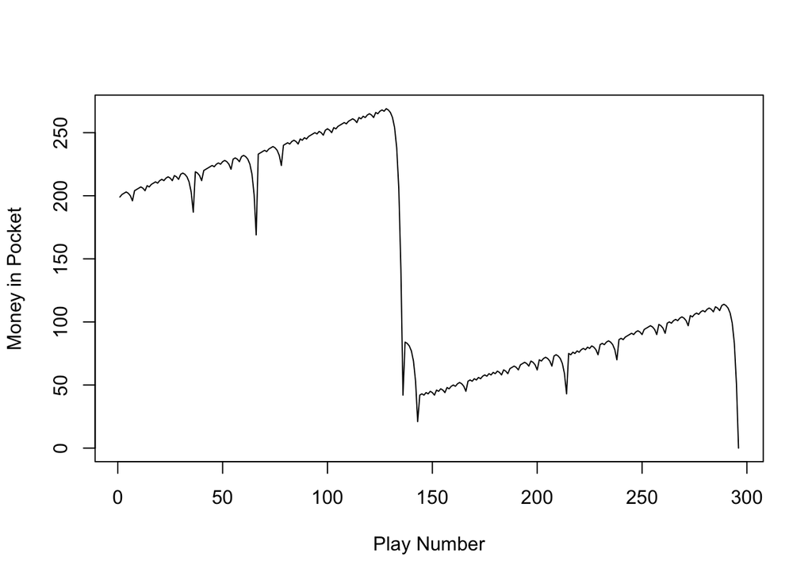

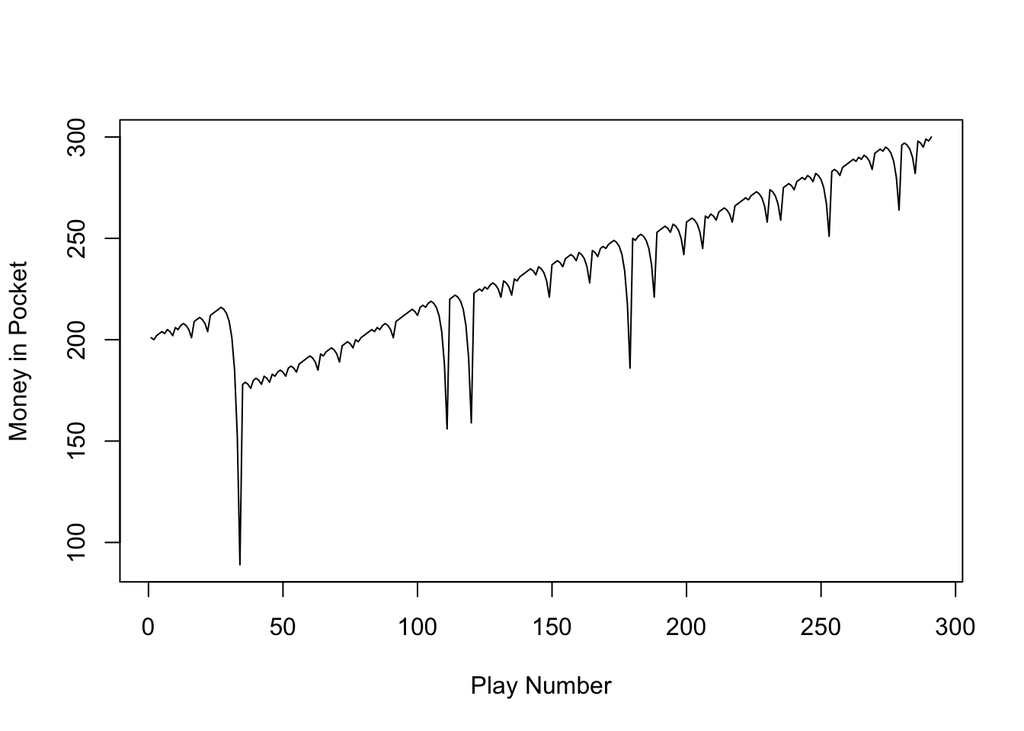

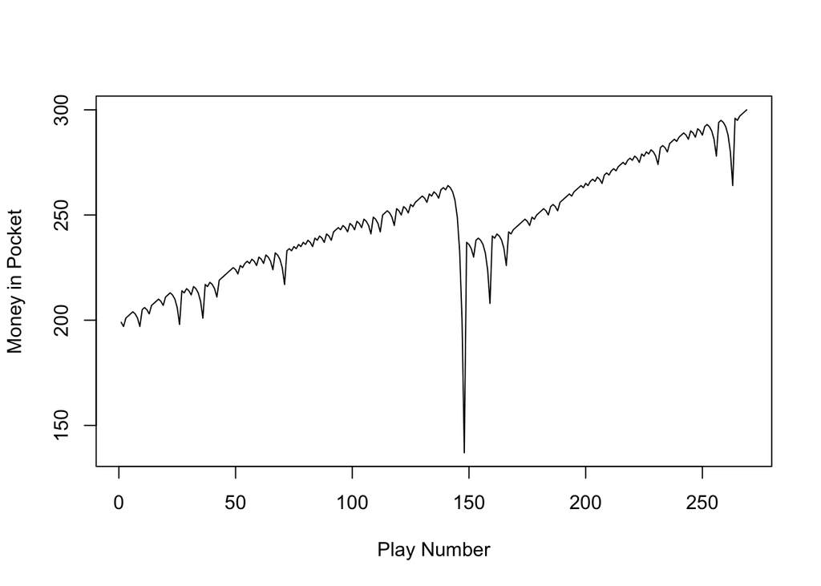

```r
library(magrittr)
#' A single play of the Martingale strategy
#'
#' Takes a state list, spins the roulette wheel, returns the state list with updated values (for example, budget, plays, etc)
#' @param state A list with the following entries:
#'   B              number, the budget
#'   W              number, the budget threshold for successfully stoping
#'   L              number, the maximum number of plays
#'   M              number, the casino wager limit
#'   plays          integer, the number of plays executed
#'   previous_wager number, the wager in the previous play (0 at first play)
#'   previous_win   TRUE/FALSE, indicator if the previous play was a win (TRUE at first play)
#' @return The updated state list
one_play <- function(state){

    # Wager
    proposed_wager <- ifelse(state$previous_win, 1, 2*state$previous_wager)
    wager <- min(proposed_wager, state$M, state$B)

    # Spin of the wheel
    red <- rbinom(1,1,18/38)

    # Update state
    state$plays <- state$plays + 1
    state$previous_wager <- wager
    if(red){
      # WIN
      state$B <- state$B + wager
      state$previous_win <- TRUE
    }else{
      # LOSE
      state$B <- state$B - wager
      state$previous_win <- FALSE
    }
  state
}


#' Stopping rule
#'
#' Takes the state list and determines if the gambler has to stop
#' @param state A list.  See one_play
#' @return TRUE/FALSE
stop_play <- function(state){
  if(state$B <= 0) return(TRUE)
  if(state$plays >= state$L) return(TRUE)
  if(state$B >= state$W) return(TRUE)
  FALSE
}


#' Play roulette to either bankruptcy, success, or play limits
#'
#' @param B number, the starting budget
#' @param W number, the budget threshold for successfully stoping
#' @param L number, the maximum number of plays
#' @param M number, the casino wager limit
#' @return A vector of budget values calculated after each play.
one_series <- function(
    B = 200
  , W = 300
  , L = 1000
  , M = 100
){

  # initial state
  state <- list(
    B = B
  , W = W
  , L = L
  , M = M
  , plays = 0
  , previous_wager = 0
  , previous_win = TRUE
  )

  # vector to store budget over series of plays
  budget <- rep(NA, L)

  # For loop of plays
  for(i in 1:L){
    new_state <- state %>% one_play
    budget[i] <- new_state$B
    if(new_state %>% stop_play){
      return(budget[1:i])
    }
    state <- new_state
  }
  budget
}

# helper function
get_last <- function(x) x[length(x)]

for(i in c(1:3)){
  one_person_play <- one_series(B = 200, W = 300, L = 1000, M = 100)

  plot(x=c(1:length(one_person_play)), y=one_person_play, type="l", xlab = "Play Number", ylab = "Money in Pocket")
}
```

```r
# Simulation
walk_out_money <- rep(NA, 5000)
for(j in seq_along(walk_out_money)){
  walk_out_money[j] <- one_series(B = 200, W = 300, L = 1000, M = 100) %>% get_last
}
```

Explanation of Tomas code: It shows that one person has $200 starting budget, when he/she earn $100, or they do not have any money, he/she will stop playing this game. maximum number of plays is 1000, and wager limit is 100. The probability of red is 18/38. The estimated probability of walking out with extra cash is 0.513. The estimated earnings would be on average -46.1. we see on average we walk out with more money more than 1/2 of the time but our earnings are still negative. I would say these parameters show the gambling game is not safe and I still hope you not to play.

The function one_play: one_play shows us how the game plays and how the variables change, for example,time of plays.Each time we play, the state$plays will plus 1, if we win the game, we will earn some money, if we lose the game, we will lose money.The probability of red(win) is 18/38.

The function one_series: one_series show us the result of one person play the game, and ‘one_series(B=200, W=300, L=1000, M=100)’ means the walk of money of this person.

## 2.1 Simulation

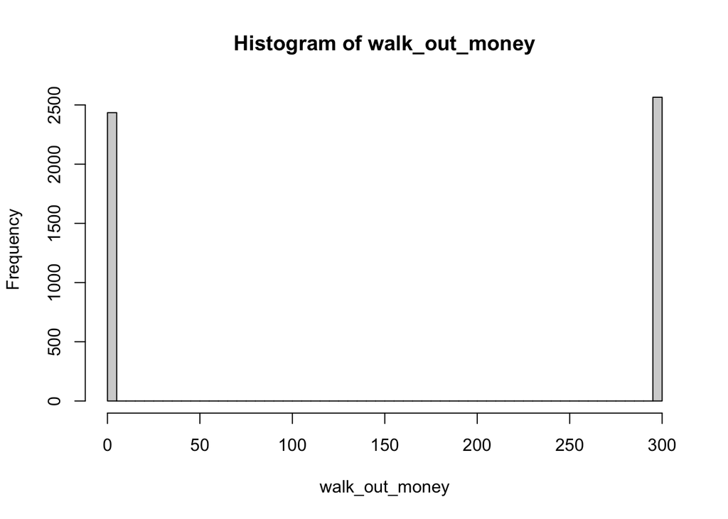

```r
# Walk out money distribution
hist(walk_out_money, breaks = 100)
```

```r
# Estimated probability of walking out with extra cash
#mean(walk_out_money > 200)

# Estimated earnings
#mean(walk_out_money - 200)
```

## 2.2 Changing the the maximum number of plays

L = 1000 changed to L=10, I hope to see that more people walk out with more than $0

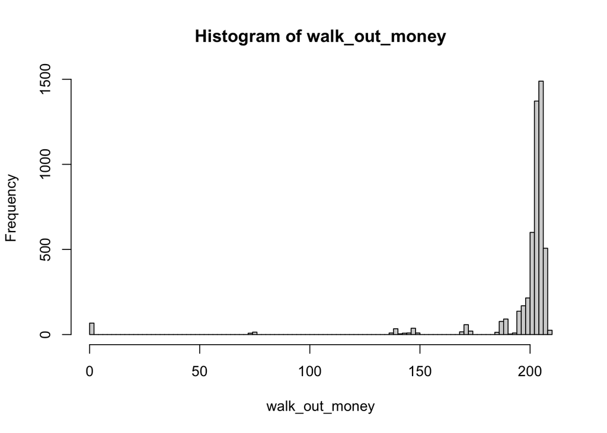

```r
# Simulation
walk_out_money <- rep(NA, 5000)
for(j in seq_along(walk_out_money)){
  walk_out_money[j] <- one_series(B = 200, W = 300, L = 10, M = 100) %>% get_last
}

# Walk out money distribution
hist(walk_out_money, breaks = 100)
```

```r
# Estimated probability of walking out with extra cash
#mean(walk_out_money > 200)

# Estimated earnings
#mean(walk_out_money - 200)
```

The Estimate probability of walking out with extra cash is 0.7986. The Estimate earnings would be on average -2.0828. more people will walk out with extra money than the simulation mentioned before.

### 2.2.1 optional plot

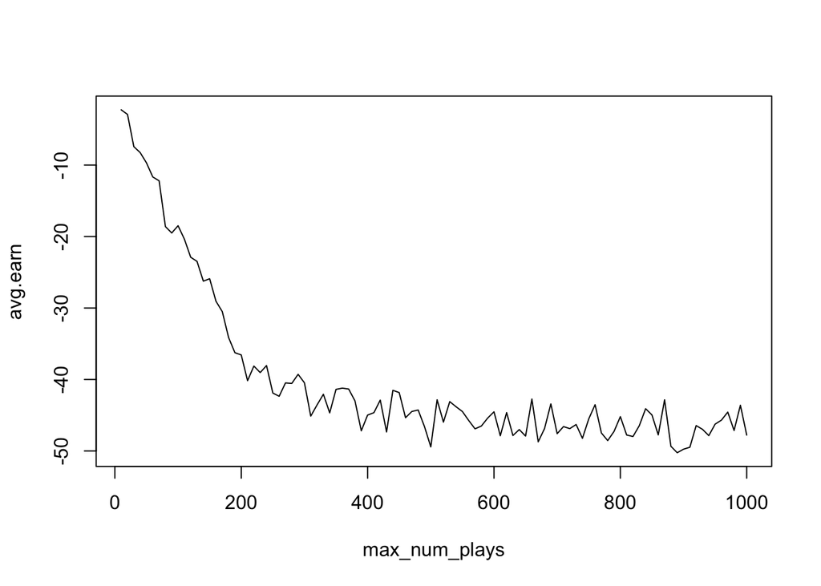

```r
library(magrittr)
max_num_plays = seq(10,1000, by=10)
avg.earn= NA

for(i in c(1:length(max_num_plays))){
  #Simulation
  walk_out_money <- rep(NA,5000)
  for (j in seq_along(walk_out_money)){
    walk_out_money[j] <- one_series(B = 200, W= 300, L = max_num_plays[i], M = 100) %>% get_last
  }
  #Estimated earnings
  avg.earn[i] = mean(walk_out_money - 200)
}

plot(x =max_num_plays, y=avg.earn, type="l")
```

Explanation of plot: The line graph shows the decreasing trend. The more time we plays, the lower earning we could get.

# 3 Stopping Rule

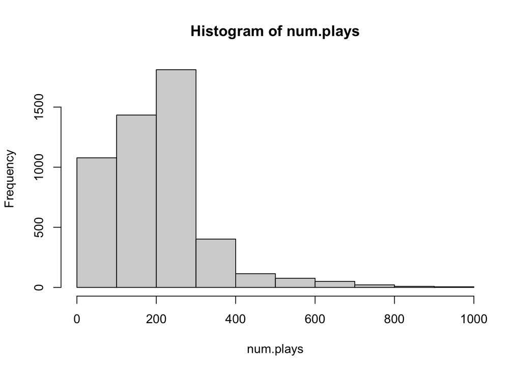

```r
# Simulation
num.plays <- rep(NA,5000)
for(j in seq_along(num.plays)){
  num.plays[j] <- one_series(B = 200, W =300, L = 1000, M = 100) %>% length()
}


#Walk out money distribution

hist(num.plays, breaks = 10)
```

```r
#mean(num.plays)
```

the mean number of plays is 201.4704 , they are estimated play 201.4704 times either win $300 or lose $200.

# 4 Conclusion

Playing roulette in the B = 200, W =300, L = 1000, M = 100 scenario is high risk to lose money. But when the L decreases, more people will walk out with extra money than the simulation mentioned before.

I do not think roulette is profitable in all situations. we could see the last but 2 graph, it shows the decreasing trend. the earning of game is lower than 0.

# 5 Limitation